# Artificial Protein Intake and Acute Kidney Injury

Exploratory Data Analysis | SUSTAIN CSX Post-hoc Study

# 1 Study Overview

## 1.1 Research Question

Is artificially administered protein intake during the first four ICU days associated with subsequent acute kidney injury (AKI) in patients undergoing major cardiac surgery?

This project is a post-hoc observational analysis of a subgroup of the SUSTAIN CSX trial. Artificial protein administration was determined by the treating physician and was not randomized.

## 1.2 Study Outcomes

| Outcome | Variable | Definition |
| --- | --- | --- |
| Primary | `AKI_any` | New AKI after ICU day 4 until ICU discharge or death |
| Secondary | `AKI_any_early` | New AKI on ICU days 5-6 |
| Exploratory | Derived from primary and secondary outcomes | AKI after ICU day 6, if derivation is valid |
| Sensitivity | `AKI_any_sensitivity_worst_case` | Patients dying without documented AKI are classified as AKI cases |

The mapping of the first two variables follows the team’s previous checks against the original modified AKI columns.

# 2 Study Population and AKI Frequencies

Overview of the study population

[output not shown]

AKI frequency under different outcome definitions

| Outcome | Patients | AKI_events | Proportion |
| --- | --- | --- | --- |
| AKI after day 6 | 293 | 43 | 14.7% |
| AKI on days 5-6 | 293 | 31 | 10.6% |
| AKI after day 4 | 293 | 74 | 25.3% |
| Worst-case AKI | 293 | 89 | 30.4% |

**Outcome consistency:** No observed nesting violations. The exploratory AKI-after-day-6 indicator was calculated from the two existing outcomes.

# 3 Missing Data

Variables containing missing observations

| Variable | Missing_n | Missing_percent |
| --- | --- | --- |
| Duration_of_cardiopulmonary_bypass_minutes | 2 | 0.7 |
| Duration_of_CPB_Quart | 2 | 0.7 |
| Duration_of_CPB_Median | 2 | 0.7 |
| SBP | 1 | 0.3 |
| SBP_Quart | 1 | 0.3 |

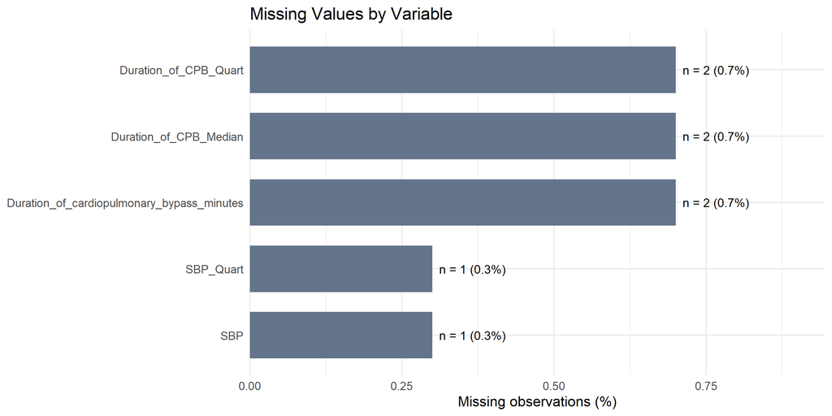

# 4 Patient Characteristics

Values are reported as median [Q1, Q3].

Patient characteristics by primary AKI status

| Variable | Overall | No_AKI | AKI |
| --- | --- | --- | --- |
| Artificial protein (g/kg/day) | 0.00 [0.00, 0.22] | 0.00 [0.00, 0.15] | 0.12 [0.00, 0.41] |
| EuroSCORE II | 10.59 [7.15, 17.16] | 9.83 [6.83, 15.71] | 13.04 [8.24, 21.57] |
| BMI | 28.00 [24.70, 31.70] | 27.77 [24.70, 31.49] | 28.75 [25.27, 32.40] |
| Cardiopulmonary bypass (min) | 159.00 [121.50, 208.00] | 155.00 [121.00, 207.00] | 169.50 [131.25, 217.25] |
| Systolic blood pressure | 110.00 [100.00, 122.00] | 110.00 [100.00, 122.00] | 110.00 [100.00, 122.00] |
| Days of exclusively oral feeding | 2.00 [0.00, 4.00] | 3.00 [0.00, 4.00] | 0.00 [0.00, 3.00] |

# 5 Artificial Protein Intake

## 5.1 Overall Distribution

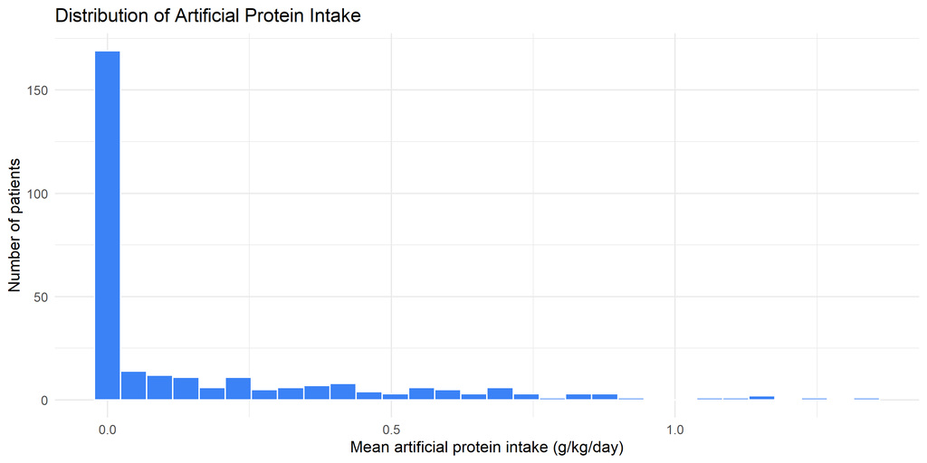

## 5.2 Positive Protein Intake Only

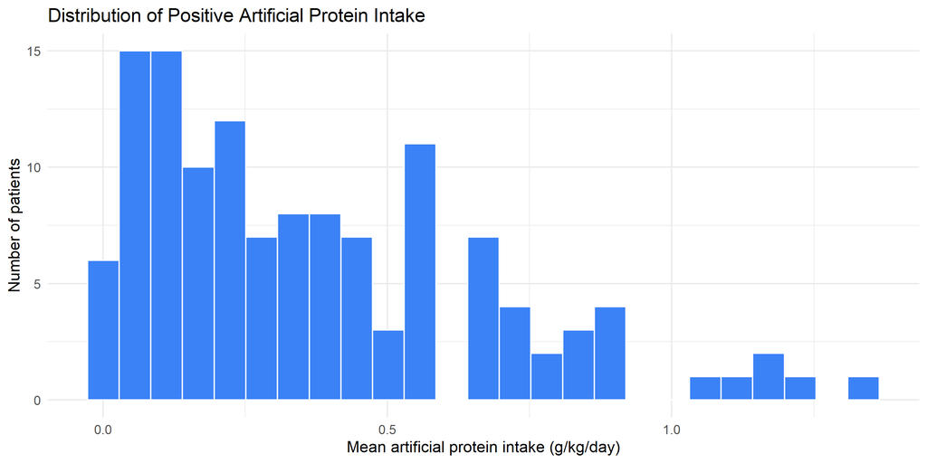

# 6 Oral Feeding and Artificial Protein Intake

Artificial protein intake by oral-feeding duration

| Oral_days | Patients | Zero | Positive | Median_protein |
| --- | --- | --- | --- | --- |
| 0 | 105 | 10 | 95 | 0.3487097 |
| 1 | 14 | 1 | 13 | 0.2136360 |
| 2 | 28 | 16 | 12 | 0.0000000 |
| 3 | 45 | 37 | 8 | 0.0000000 |
| 4 | 101 | 101 | 0 | 0.0000000 |

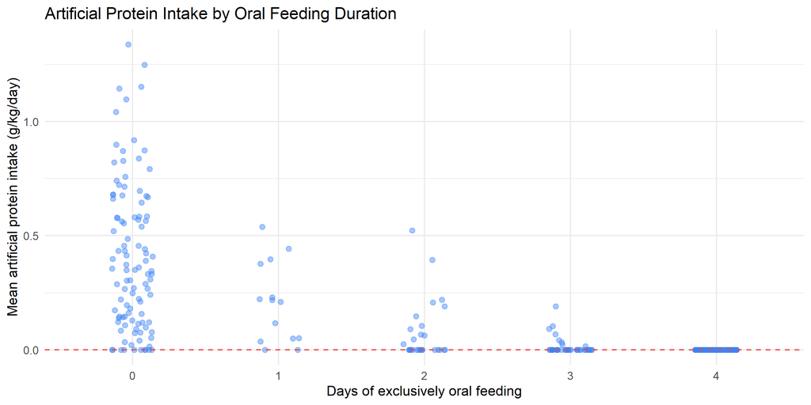

Patients with four days of exclusively oral feeding received no artificially administered protein. This creates a lack of exposure overlap within that group.

# 7 Observed AKI by Artificial Protein Intake

This comparison includes the primary, secondary, worst-case, and—if valid—derived late AKI outcomes.

For comparability, patients must have nonmissing protein intake and all three original AKI outcomes.

Observed AKI by artificial protein intake

| Outcome | Protein_group | Patients | AKI_events | AKI_percent |
| --- | --- | --- | --- | --- |
| AKI after day 4 | Zero | 165 | 24 | 14.5 |
| AKI after day 4 | Positive | 128 | 50 | 39.1 |
| AKI on days 5-6 | Zero | 165 | 13 | 7.9 |
| AKI on days 5-6 | Positive | 128 | 18 | 14.1 |
| AKI after day 6 | Zero | 165 | 11 | 6.7 |
| AKI after day 6 | Positive | 128 | 32 | 25.0 |
| Worst-case AKI | Zero | 165 | 24 | 14.5 |
| Worst-case AKI | Positive | 128 | 65 | 50.8 |

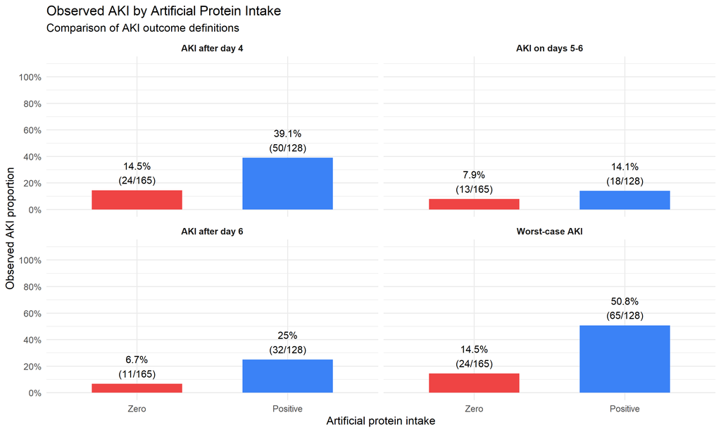

These proportions are descriptive and unadjusted. The different AKI outcomes cover different observation periods or assumptions.

# 8 Primary AKI by Oral Feeding Duration

[figure not shown]

[figure not shown]

# 9 Mortality Sensitivity Analysis

The worst-case outcome reclassifies patients who died in the ICU without documented AKI as AKI cases.

This comparison identifies how many patients change classification.

Primary versus worst-case AKI classification

| Patients | Primary_AKI | Worst_case_AKI | Reclassified_to_AKI | Reclassified_from_AKI |
| --- | --- | --- | --- | --- |
| 293 | 74 | 89 | 15 | 0 |

Mortality among reclassified patients

| Death_status | Patients |
| --- | --- |
| Unknown | 15 |

The worst-case analysis examines sensitivity to the handling of death. It does not establish that the reclassified patients actually developed AKI.

# 10 Clinical Variables and Potential Confounding

## 10.1 Clinical Characteristics by AKI Status

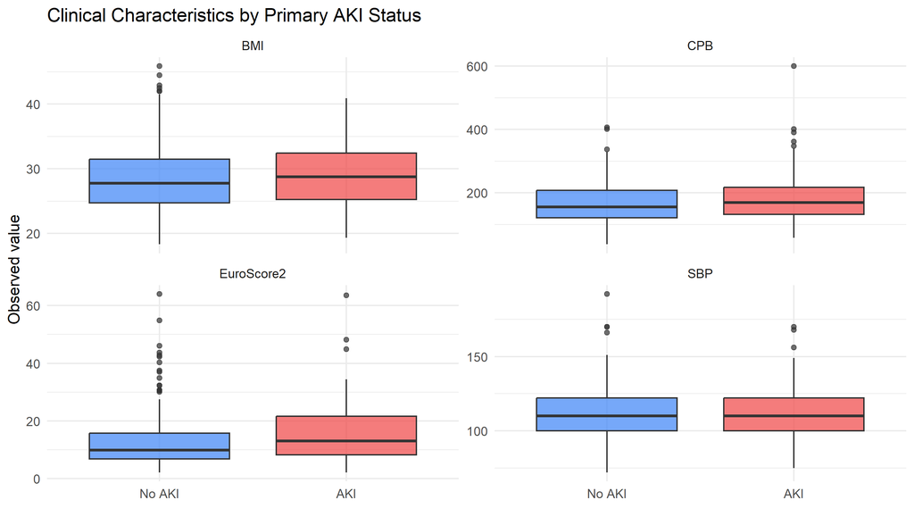

## 10.2 Clinical Characteristics and Artificial Protein Intake

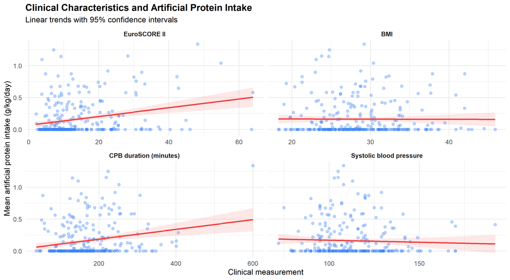

These descriptive relationships can help identify variables requiring clinical consideration, but correlations alone do not establish confounding.

## 10.3 CLINICAL CHARACTERISTICS BY PROTEIN GROUP EuroSCORE II, CPB duration and BMI

Clinical characteristics by artificial protein intake group

| Variable | Protein_group | n | Summary |
| --- | --- | --- | --- |
| EuroSCORE II | Zero | 165 | 9.36 [5.94, 13.19] |
| EuroSCORE II | Positive | 128 | 12.87 [8.38, 20.86] |
| CPB duration (minutes) | Zero | 164 | 143.50 [108.50, 181.00] |
| CPB duration (minutes) | Positive | 127 | 174.00 [132.00, 237.50] |
| BMI (kg/m²) | Zero | 165 | 27.56 [24.70, 31.50] |
| BMI (kg/m²) | Positive | 128 | 28.40 [25.18, 31.83] |

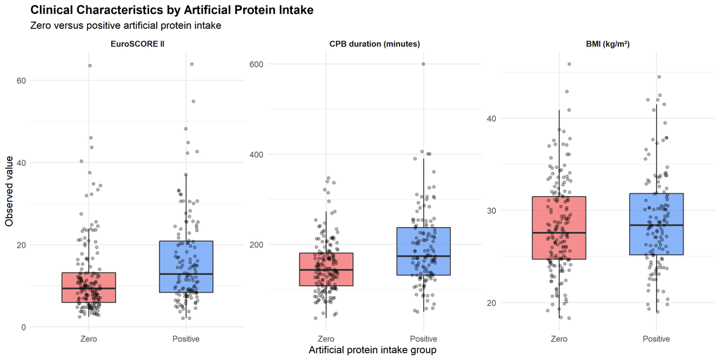

# 11 Readiness for Regression Analysis

Data availability for the candidate primary regression model

| Measure | Count |
| --- | --- |
| Patients with complete model data | 290 |
| AKI events in complete cases | 73 |
| Non-AKI patients in complete cases | 217 |

# 12 Conclusions and Next Steps

The exploratory analysis examines the distributions of artificial protein intake, AKI outcomes, oral-feeding duration, and selected clinical characteristics.

Key methodological considerations:

- **Confounding by indication:** Artificial protein administration was determined by the treating physician.
- **Exposure overlap:** Four days of exclusive oral feeding correspond to zero artificially administered protein.
- **Competing events:** In-ICU death can prevent subsequent AKI from being observed.
- **Outcome timing:** The primary, secondary, and derived late AKI outcomes cover different observation windows.
- **Observational interpretation:** Descriptive differences cannot establish a causal effect of protein intake.

The next stage is to specify a clinically justified adjustment set, fit the primary regression model, assess model assumptions, and perform the predefined secondary and mortality sensitivity analyses.

# 13 References

1. Project proposal (24 July 2026). *Acute kidney injury after major cardiac surgery: the association with protein intake in the acute phase.*
2. Project partner’s written responses concerning eligibility, artificial nutrition, and mortality sensitivity analysis.
3. Stoppe C, et al. (2023). *Effect of High-Dose Selenium on Postoperative Organ Dysfunction and Mortality in Cardiac Surgery Patients.* JAMA Surgery. https://doi.org/10.1001/jamasurg.2022.6855

**Data protection:** The report processes the clinical dataset locally. Small cell counts and potentially identifiable information must be reviewed before sharing the HTML output.